# DEBIPM - Sum of sensitivities

Viktor Thunell

2022-01-27

### Sensitivity of lambda to kappa - comparison of total and decomposed sensitivity

A quick reminder: We do a sensitivity (perturbation) analysis across different temperatures to study which demographic processes, and the size at which they occur, affect how optimal energy allocation changes with warming. We analyze the partial contribution of each of o(T) (size at age 1), f(x,T) (fecundity) and g(y:x,T) (somatic growth) to sensitivity of $\lambda$ to changes in energy allocation (κ_0) at three different temperatures to understand how size dependent vital rates affects optimum.

In this document I compare the size specific and total sum of the sensitivity contributions from demographic functions calculated in this analysis (point 3 below) with the sensitivity of lambda to a perturbation of $\kappa_0$ )(point 1) and the sum of the size dependent sensitivity to a perturbation of the kernel matrix (point 2). This corresponds to a comparison of the first, third and last equality in

$$\begin{align}\label{sensitkappa}
\frac{d \lambda}{d\kappa_0}&=\sum_{i=1}^{n+1}\sum_{j=1}^{n+1}\frac{d \lambda}{dK_{ij}}\frac{d K_{ij}}{d\kappa_0}\\
&=\sum_{i=1}^{n+1}\sum_{j=1}^{n+1}v_iw_j\frac{d K_{ij}}{d\kappa_0}\\
&=\sum_{j=2}^{n+1}v_1w_ja_j\frac{df_j}{d\kappa_0}+\sum_{i=2}^{n+1}v_iw_1a_1\frac{dg_{i1}}{d\kappa_0}+\sum_{i=2}^{n+1}\sum_{j=2}^{n+1}v_iw_ja_j\frac{dg_{ij}}{d\kappa_0}.
\end{align}$$

### Create v and w for optimal $\kappa_0$ at three temperatures

```r
#Optimum kappa at three temperatures (from produced results)
OptPars <- as.data.frame(cbind(T = c(287,289,291), kappa=c(0.99,0.95,0.92), Y=c(1,1,1)))

# Create results for v and w. This takes a few minutes
Res_v287 <- c(T=OptPars[1,1], kappa=OptPars[1,2], Y=1,
            wvlambda.projection(K.matrix(OptPars[1,]))$v)
Res_w287 <- c(T=OptPars[1,1], kappa=OptPars[1,2], Y=1,
              wvlambda.projection(K.matrix(OptPars[1,]))$w)

Res_v289 <- c(T=OptPars[2,1], kappa=OptPars[2,2], Y=1,
              wvlambda.projection(K.matrix(OptPars[2,]))$v)
Res_w289 <- c(T=OptPars[2,1], kappa=OptPars[2,2], Y=1,
              wvlambda.projection(K.matrix(OptPars[2,]))$w)

Res_v291 <- c(T=OptPars[3,1], kappa=OptPars[3,2], Y=1,
              wvlambda.projection(K.matrix(OptPars[3,]))$v)
Res_w291 <- c(T=OptPars[3,1], kappa=OptPars[3,2], Y=1,
              wvlambda.projection(K.matrix(OptPars[3,]))$w)

Res_v <- as.data.frame(rbind(Res_v287, Res_v289, Res_v291))
colnames(Res_v)[4:ncol(Res_v)] <- c(0,x)
Res_w <- as.data.frame(rbind(Res_w287, Res_w289, Res_w291))
colnames(Res_w)[4:ncol(Res_w)] <- c(0,x)
```

### Functions for numerical differentiation (difference forward differentiation)

i.e. ( f(x + h) - f(x) ) / h) ) of dK/dk_0, dGrowth/dk_0, dFecundityiy/dk_0 and dAge1/k_0.

```r
# Kernel level pert.
K_NumDer <- function(h, Pars){
  (K.matrix(Pars = c(T = Pars[["T"]],kappa = Pars[["kappa"]] + h,Y = Pars[["Y"]])) -
     K.matrix(Pars = c(T = Pars[["T"]],kappa = Pars[["kappa"]],Y = Pars[["Y"]])))/h
}
# Growth function pert.
G_NumDer <- function(h ,m, Pars){
  (DEBgrowthfun(m, Pars = c(T = Pars[["T"]],kappa = Pars[["kappa"]] + h,Y = Pars[["Y"]])) -
     DEBgrowthfun(m, Pars = c(T = Pars[["T"]],kappa = Pars[["kappa"]],Y = Pars[["Y"]])))/h
}
# Fecundity function pert.
F_NumDer <- function(h ,m, Pars){
  (DEBrepfun(m, Pars = c(T = Pars[["T"]],kappa = Pars[["kappa"]] + h,Y = Pars[["Y"]])) -
   DEBrepfun(m, Pars = c(T = Pars[["T"]],kappa = Pars[["kappa"]],Y = Pars[["Y"]])))/h
}
# Age 1 size function pert.
A1_NumDer <- function(h ,m, Pars){
  (DEBage1.size(Pars = c(T = Pars[["T"]],kappa = Pars[["kappa"]] + h,Y = Pars[["Y"]])) -
     DEBage1.size(Pars = c(T = Pars[["T"]],kappa = Pars[["kappa"]],Y = Pars[["Y"]])))/h
}
```

### 1 - Calculate $d\lambda/d\kappa_0$ at 287 Kelvin

```r
(wvlambda.projection(K.matrix(Pars = c(T = OptPars[1,1],kappa = OptPars[1,2]
                                       + 0.00001, Y = OptPars[1,3])))$lam
 -
 wvlambda.projection(K.matrix(Pars = c(T = OptPars[1,1],kappa = OptPars[1,2], Y = OptPars[1,3])))$lam) / 0.00001
```

```
## [1] -0.04407772
```

The sensitivity of $\lambda$ to a perturbation of $\kappa_0$ is -0.04407772.

## 2 - Calculate total size dependent sensitivity at 287 K by perturbing the K.matrix at optimal $\kappa_0$ at 287 K

```r
res_v <- as.numeric(Res_v %>% filter(T == OptPars[1,1] & kappa==OptPars[1,2]))[4:ncol(Res_v)]
  res_w <- as.numeric(Res_w %>% filter(T == OptPars[1,1] & kappa==OptPars[1,2]))[4:ncol(Res_w)]

Sens_Kmat <- outer(res_v, res_w, "*") * K_NumDer(0.00001, OptPars[1,])

sum(apply(Sens_Kmat,1,sum))
```

```
## [1] -0.04404539
```

The total sum here (-0.04404539) is very close to the sensitivity of lambda to $\kappa_0$. I compare the size dependent sensitivity from these calculations to the summed demographic contributions in a plot in point below.

### 3 - Contributions to size dependent sensitivity from demographic functions

This is the analysis that go into the manuscript main text. I have done two major changes since the last draft: First I now use the transposed survival vector and numerical perturbation of the growth matrix when calculating Gr_cont below, i.e. how we calculate growth in the K.matrix (compare line 207 in Rscript_DEBIPM_model_20220123). Second, in the calculation for growth and age 1 size I multiply with dx).

```r
Res_Sens <- NULL
for (i in 1:nrow(OptPars)){
  res_v <- as.numeric(Res_v %>% filter(T == OptPars[i,1] & kappa==OptPars[i,2]))[4:ncol(Res_v)]
  res_w <- as.numeric(Res_w %>% filter(T == OptPars[i,1] & kappa==OptPars[i,2]))[4:ncol(Res_w)]

  Gr_cont <- bind_cols(Size=x, Temp=OptPars[i,1], kappa=OptPars[i,2],
                       dfun="Gr", outer(res_v[2:(n+1)], res_w[2:(n+1)], "*")
                       * t(DEBsurvfun(x, OptPars[i,]) * t(G_NumDer(h=0.00001, x, OptPars[i,])))*dx)
  Gr_cont["Sens"] <- apply(Gr_cont[5:ncol(Gr_cont)],1,FUN=sum)# sum the distribution y to get sensitivity for each size
  Gr_cont<-Gr_cont[,c(1:4,ncol(Gr_cont))]

  F_cont  <- bind_cols(Size=x, Temp=OptPars[i,1], kappa=OptPars[i,2],
                       dfun="F",  Sens=res_v[1]*res_w[2:(n+1)]
                       * DEBsurvfun(x, OptPars[i,]) * F_NumDer(h=0.00001, x, OptPars[i,]))

  A1_cont <- bind_cols(Size=x, Temp=OptPars[i,1], kappa=OptPars[i,2],
                       dfun="A1", Sens=res_v[2:(n+1)]*res_w[1]
                       * el_surv * A1_NumDer(h=0.00001, x, OptPars[i,])*dx)

  Res_Sens <- rbind(rbind(Gr_cont,F_cont,A1_cont), Res_Sens)
}

# sum the contributions from demographic functions at each size
Sum_cont <-
  Res_Sens %>%
  group_by(Size, Temp) %>%
  summarise(sum.t = sum(Sens, na.rm = TRUE))
sum(Sum_cont[Sum_cont$Temp==287,]$sum.t) # Same as in both in 1 and 2 ~ -0.04404539
```

```
## [1] -0.04404539
```

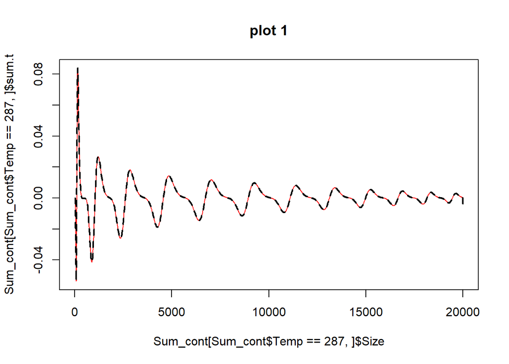

```r
plot(Sum_cont[Sum_cont$Temp==287,]$Size,Sum_cont[Sum_cont$Temp==287,]$sum.t, type = "l", col="red", main = "plot 1")
#lines(x,apply(Sens_Kmat[2:(n+1),],1,sum), type = "l")
lines(x,Sens_Kmat[1,2:(n+1)]+apply(Sens_Kmat[2:(n+1),],1,sum), lty=2, lwd=2) # So here I add the sensitivity contribution from fecundity (first row) to the rest of the sensitivity
```

So I get the same results in my comparisons of both total and size dependent sensitivity with the dempgraphic function contributions to sensitivity.

The deviation of the total sensitivity from zero could be due to that our optimum $\kappa_0$ is not exact. When I produce the model results, the values in the kappa range differ by 0.01, I guess that the optimum kappa used in the sensitivity analyses may not be precise enough to sum to zero.

### 4 - Plot sensitivity contributions (figure main text)

```r
library(tidyverse) # gglot etc.

s_sum <- Res_Sens %>%
  group_by(dfun, Temp) %>%
  summarise(sum.c = sum(Sens, na.rm = TRUE)) #%>%
```

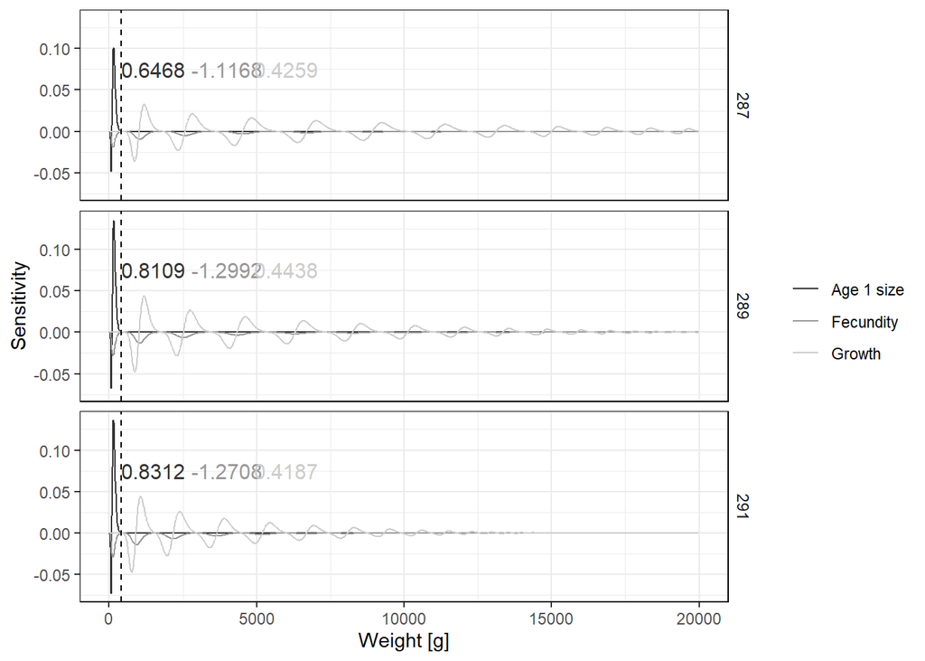

```r
s_sum_text <- data.frame(Size = c(1500,1500,1500,4000,4000,4000,6000,6000,6000), Sens = 0.075,
                         dfun = s_sum$dfun, Temp = s_sum$Temp, label = round(s_sum$sum.c,4))

cont.labs <- c("Age 1 size", "Fecundity", "Growth")
names(cont.labs) <- c("A1", "F", "Gr")

Fig_sens <-
Res_Sens %>%
  mutate(dfun=as.factor(dfun)) %>%
  ggplot(.) +
  geom_path(aes(Size, Sens, color = dfun)) +
  facet_grid(Temp~., scales="fixed") +
  xlim(0,20000) +
  geom_vline(xintercept=400, linetype="dashed") +
  ylab("Sensitivity") +
  xlab("Weight [g]") +
  scale_color_grey(labels= cont.labs, name= "",) +
  geom_text(data=s_sum_text, aes(Size, Sens, label = label,
                              colour=dfun), size=4, show.legend = FALSE) +
  theme_bw() +
  theme(panel.background = element_rect(fill = "white", colour = "black"),
        strip.background = element_blank(),
        panel.border = element_rect(colour = "black", fill = NA))
Fig_sens
```